# **Flow-Based Network Intrusion Detection (Multiclass Classification)**

#### Author: Luis Rito Filipe

#### July, 2023

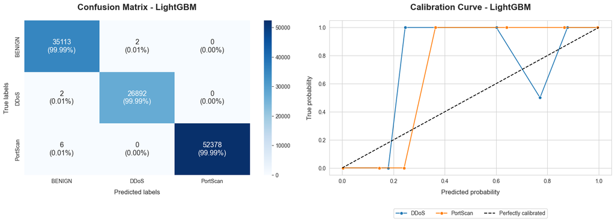

# Summary

The following study extends a previous binary classification analysis of network traffic into a multiclass framework, with the objective of distinguishing between BENIGN traffic, DDoS attacks and PortScan activity. While the binary formulation focused solely on separating normal from malicious traffic, the multiclass approach provides a more granular understanding of network behavior by identifying specific types of malicious activity.

The analysis followed a structured pipeline, beginning with exploratory data analysis and statistical feature evaluation. Key variables such as Subflow Fwd Bytes and Packet Length Std were identified as highly discriminative, showing clear distributional differences across traffic classes. These findings were consistent across both the binary and multiclass formulations, reinforcing the robustness of the underlying data patterns.

Among the evaluated models, LightGBM was selected as the final model due to its superior balance of performance metrics and stable probabilistic outputs. The confusion matrix confirmed near-perfect classification with negligible misclassification and no confusion between malicious traffic types. Calibration analysis further demonstrated that predicted probabilities are well aligned with observed outcomes, particularly in high-confidence regions.

Feature importance analysis showed that a small subset of variables drives the model’s predictions, with Subflow Fwd Bytes and Packet Length Std playing a dominant role. This aligns with earlier statistical findings and reflects meaningful behavioral differences between benign and malicious traffic.

Error analysis revealed that misclassifications are extremely rare and primarily limited to borderline cases between BENIGN and PortScan traffic, with almost no impact on DDoS detection.

Overall, the multiclass formulation provides a more informative and operationally valuable model compared to the binary approach, enabling not only the detection of malicious traffic but also its categorization. The selected model demonstrates high predictive performance, strong reliability, and clear interpretability, making it suitable for deployment in real-world intrusion detection systems.

# About The Study

The objective of this study is to classify various types of malicious and benign traffic using data analysis and machine learning algorithms. To achieve this, I will leverage widely used Python libraries specialized in data analysis and machine learning, including tools for data manipulation, visualization, and predictive modeling. The study will progress from exploratory data analysis to more advanced techniques, such as feature engineering, to provide meaningful insights into the characteristics of malicious traffic detection. This study follows the binary classification study applied to the same dataset ([Flow-based network intrusion (binary classification)](https://luisritofilipe.github.io/data_science_learning/Flow_based_network_intrusion_binary_classification.html)).

# About The Dataset

The following study uses a dataset of network intrusion publicly available from Kaggle (see link below). The dataset was produced by Canadian Institute for Cybersecurity.

Dataset link: https://www.kaggle.com/datasets/chethuhn/network-intrusion-dataset

# Methodology

- Data Wrangling and Preprocessing
- Exploratory Data Analysis and Feature Evaluation
- Model Training
- Model Comparison and Selection
- Feature Importance Analysis
- Error and Calibration Analysis
- Final Evaluation and Conclusion

# Data Wrangling and Preprocessing

Two datasets with exact the same 79 features, one with DDoS attacks and other with PortScan-related traffic, were used. After loading and merging the datasets, data was prepared.

```
<class 'pandas.core.frame.DataFrame'>
RangeIndex: 512212 entries, 0 to 512211
Columns: 79 entries,  Destination Port to  Label
dtypes: float64(24), int64(54), object(1)
memory usage: 308.7+ MB
```

|  | Destination Port | Flow Duration | Total Fwd Packets | Total Backward Packets | Total Length of Fwd Packets | Total Length of Bwd Packets | Fwd Packet Length Max | Fwd Packet Length Min | Fwd Packet Length Mean | Fwd Packet Length Std | Bwd Packet Length Max | Bwd Packet Length Min | Bwd Packet Length Mean | Bwd Packet Length Std | Flow Bytes/s | Flow Packets/s | Flow IAT Mean | Flow IAT Std | Flow IAT Max | Flow IAT Min | Fwd IAT Total | Fwd IAT Mean | Fwd IAT Std | Fwd IAT Max | Fwd IAT Min | Bwd IAT Total | Bwd IAT Mean | Bwd IAT Std | Bwd IAT Max | … |
| --- | --- | --- | --- | --- | --- | --- | --- | --- | --- | --- | --- | --- | --- | --- | --- | --- | --- | --- | --- | --- | --- | --- | --- | --- | --- | --- | --- | --- | --- | --- |
| count | 512212.000000 | 5.122120e+05 | 512212.000000 | 512212.000000 | 512212.000000 | 5.122120e+05 | 512212.000000 | 512212.000000 | 512212.000000 | 512212.000000 | 512212.000000 | 512212.000000 | 512212.000000 | 512212.000000 | 5.121930e+05 | 5.122120e+05 | 5.122120e+05 | 5.122120e+05 | 5.122120e+05 | 5.122120e+05 | 5.122120e+05 | 5.122120e+05 | 5.122120e+05 | 5.122120e+05 | 5.122120e+05 | 5.122120e+05 | 5.122120e+05 | 5.122120e+05 | 5.122120e+05 | … |
| mean | 8412.769090 | 1.016663e+07 | 4.091019 | 3.984264 | 544.584561 | 4.141029e+03 | 282.666408 | 18.078026 | 86.143519 | 108.468259 | 1309.471908 | 22.736429 | 435.251879 | 573.344087 | inf | inf | 8.887531e+05 | 2.246625e+06 | 6.963890e+06 | 1.883560e+04 | 9.724758e+06 | 1.555440e+06 | 2.574144e+06 | 6.718783e+06 | 3.421505e+05 | 5.671966e+06 | 8.635275e+05 | 9.312839e+05 | 2.890904e+06 | … |
| std | 17447.963843 | 2.712714e+07 | 17.841275 | 25.620921 | 2592.815800 | 4.619398e+04 | 1281.867186 | 110.274825 | 347.365649 | 544.842538 | 2800.858963 | 52.869257 | 860.129260 | 1298.281072 | NaN | NaN | 2.473728e+06 | 6.080575e+06 | 1.983521e+07 | 5.790381e+05 | 2.704408e+07 | 6.023558e+06 | 7.771771e+06 | 2.023747e+07 | 5.002368e+06 | 2.159339e+07 | 5.574226e+06 | 4.089487e+06 | 1.265023e+07 | … |
| min | 0.000000 | -1.300000e+01 | 1.000000 | 0.000000 | 0.000000 | 0.000000e+00 | 0.000000 | 0.000000 | 0.000000 | 0.000000 | 0.000000 | 0.000000 | 0.000000 | 0.000000 | -1.930000e+08 | -2.000000e+06 | -1.300000e+01 | 0.000000e+00 | -1.300000e+01 | -1.300000e+01 | 0.000000e+00 | 0.000000e+00 | 0.000000e+00 | 0.000000e+00 | -1.200000e+01 | 0.000000e+00 | 0.000000e+00 | 0.000000e+00 | 0.000000e+00 | … |
| 25% | 80.000000 | 5.500000e+01 | 1.000000 | 1.000000 | 2.000000 | 6.000000e+00 | 2.000000 | 0.000000 | 2.000000 | 0.000000 | 6.000000 | 0.000000 | 6.000000 | 0.000000 | 1.568228e+02 | 3.160119e+00 | 5.333333e+01 | 0.000000e+00 | 5.500000e+01 | 3.000000e+00 | 0.000000e+00 | 0.000000e+00 | 0.000000e+00 | 0.000000e+00 | 0.000000e+00 | 0.000000e+00 | 0.000000e+00 | 0.000000e+00 | 0.000000e+00 | … |
| 50% | 146.000000 | 3.027600e+04 | 2.000000 | 1.000000 | 26.000000 | 6.000000e+00 | 6.000000 | 2.000000 | 6.000000 | 0.000000 | 6.000000 | 6.000000 | 6.000000 | 0.000000 | 2.634817e+04 | 1.656658e+02 | 7.943167e+03 | 1.154744e+02 | 2.456900e+04 | 2.200000e+01 | 3.000000e+00 | 3.000000e+00 | 0.000000e+00 | 3.000000e+00 | 1.000000e+00 | 0.000000e+00 | 0.000000e+00 | 0.000000e+00 | 0.000000e+00 | … |
| 75% | 5544.000000 | 2.033681e+06 | 4.000000 | 4.000000 | 62.000000 | 3.500000e+02 | 36.000000 | 6.000000 | 33.000000 | 6.094494 | 191.250000 | 6.000000 | 159.000000 | 9.899495 | 1.666667e+05 | 3.636364e+04 | 3.703694e+05 | 8.667981e+05 | 1.989960e+06 | 5.600000e+01 | 2.799100e+05 | 6.571646e+04 | 3.254759e+04 | 1.933665e+05 | 4.600000e+01 | 1.108765e+05 | 2.356893e+04 | 2.751521e+04 | 8.520375e+04 | … |
| max | 65532.000000 | 1.199999e+08 | 3119.000000 | 3635.000000 | 232349.000000 | 7.150819e+06 | 13929.000000 | 1472.000000 | 3867.000000 | 6692.644993 | 11680.000000 | 1460.000000 | 5800.500000 | 8194.660487 | inf | inf | 1.070000e+08 | 8.480000e+07 | 1.200000e+08 | 1.070000e+08 | 1.200000e+08 | 1.200000e+08 | 8.120000e+07 | 1.200000e+08 | 1.200000e+08 | 1.200000e+08 | 1.200000e+08 | 8.130000e+07 | 1.200000e+08 | … |

In this study only a subset from the 79 initial features was used (Flow Bytes/s, Flow Packets/s, Fwd Packets/s, Bwd Packets/s, Subflow Fwd Packets, Subflow Fwd Bytes, Packet Length Std, Packet Length Variance, Flow Duration, Init_Win_bytes_forward, Init_Win_bytes_backward, Down/Up Ratio, Label).

There are 10 features with only one unique value, which imply they have zero variance and cannot help distinguishing the different classes. Mathematically, for models like logistic regression, the coefficient becomes meaningless and it may even cause numerical instability in some cases. If any of these were included in the subset used, it would also be removed.

Label feature contains three unique values, namely "BENIGN", "DDoS" and "PortScan", which will be encoded to integers. Label feature was renamed to Class. A space before or after each feature name was removed. A few rows with infinite values were removed. Rows with values of -1 in features "Init_Win_bytes_forward" and "Init_Win_bytes_backward" were removed as this is an indication that the information was not available or not applicable for a particular flow.

```
{'BENIGN': np.int64(0), 'DDoS': np.int64(1), 'PortScan': np.int64(2)}
```

```
array([106407,  81497, 158740])
```

# Exploratory Data Analysis and Feature Evaluation

Feature correlation analysis helped identify strongly correlated feature pairs, allowing for the removal of redundant variables and improving model robustness. A correlation threshold of 0.95 was defined, such that if two independent variables exhibited a correlation equal to or greater than this value, one of them would be removed. This approach helps mitigate multicollinearity and reduces the risk of overfitting, particularly in linear models.

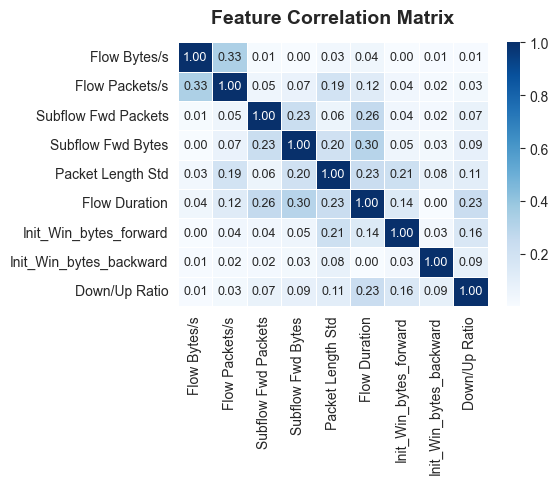

Below, the summary statistics of the dataset reduced and prepared for the machine learning algorithms.

|  | Flow Bytes/s | Flow Packets/s | Subflow Fwd Packets | Subflow Fwd Bytes | Packet Length Std | Flow Duration | Init_Win_bytes_forward | Init_Win_bytes_backward | Down/Up Ratio | Class |
| --- | --- | --- | --- | --- | --- | --- | --- | --- | --- | --- |
| count | 3.466440e+05 | 3.466440e+05 | 346644.000000 | 346644.000000 | 346644.000000 | 3.466440e+05 | 346644.000000 | 346644.000000 | 346644.000000 | 346644.000000 |
| mean | 1.648106e+05 | 3.464620e+04 | 4.674046 | 774.300178 | 746.880217 | 1.357641e+07 | 11308.381547 | 1337.718048 | 1.110866 | 1.150970 |
| std | 1.571201e+06 | 1.193475e+05 | 21.462025 | 3124.136830 | 1134.641265 | 3.164487e+07 | 12910.440954 | 6922.772750 | 1.129737 | 0.861456 |
| min | -1.930000e+08 | -2.000000e+06 | 1.000000 | 0.000000 | 0.000000 | -1.300000e+01 | 0.000000 | 0.000000 | 0.000000 | 0.000000 |
| 25% | 5.948222e+02 | 4.353305e+00 | 1.000000 | 0.000000 | 2.309401 | 4.800000e+01 | 1024.000000 | 0.000000 | 1.000000 | 0.000000 |
| 50% | 8.695652e+04 | 1.526718e+04 | 1.000000 | 6.000000 | 3.464102 | 1.520000e+02 | 8192.000000 | 0.000000 | 1.000000 | 1.000000 |
| 75% | 1.600000e+05 | 4.255319e+04 | 3.000000 | 50.000000 | 1633.102694 | 1.856222e+06 | 29200.000000 | 229.000000 | 1.000000 | 2.000000 |
| max | 6.170000e+08 | 3.000000e+06 | 3119.000000 | 232349.000000 | 4731.522394 | 1.199999e+08 | 65535.000000 | 65535.000000 | 124.000000 | 2.000000 |

Due to the large skewness of the ANOVA F-statistics, a logarithmic transformation was applied to improve visualization and facilitate comparison between features.

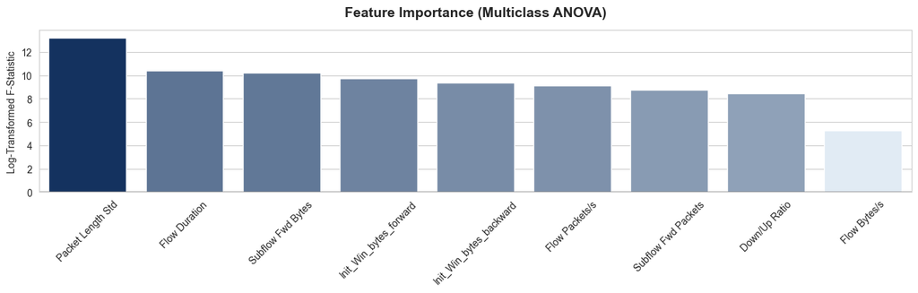

The ANOVA F-test in the following chart indicates that Packet Length Std is one of the most discriminative features in the dataset, showing a significantly higher score compared to all other features, suggesting this feature strongly separates normal traffic from DDoS attacks and PortScan-related traffic. This result is supported by the boxplot analysis.

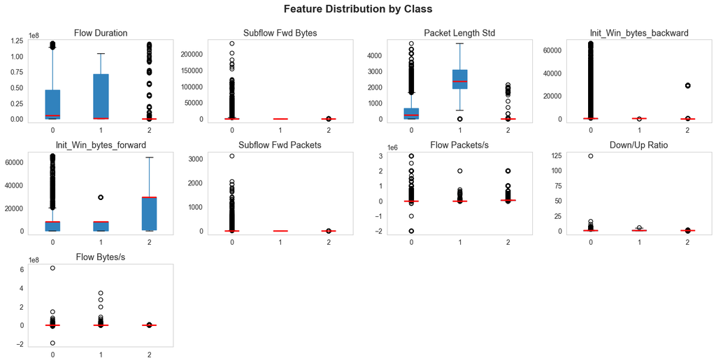

The boxplot analysis highlights a clear separation between classes driven by a small subset of features. Subflow Fwd Bytes exhibits a highly compressed distribution across all classes, indicating low variability for most observations. However, class 0 (BENIGN traffic) presents several extreme outliers, suggesting that while normal traffic is generally stable, it can occasionally display large deviations.

Packet Length Std shows distinct patterns across classes. Class 0 is concentrated in the lower range with a compact distribution and a few extreme values. In contrast, class 1 (DDoS) displays a wider interquartile range, indicating higher intrinsic variability. Class 2 (PortScan) presents a compressed distribution with some moderate outliers. Notably, there is minimal overlap between class interquartile ranges, indicating strong discriminative power for this feature.

Init_Win_bytes_backward is tightly concentrated in the lower range for all classes, but class 0 again shows a significant number of outliers. In contrast, Flow Duration shows higher variability for classes 0 and 1, with substantial overlap in their interquartile ranges, limiting its ability to separate these classes. Class 2 remains more compact, although some outliers are present.

Init_Win_bytes_forward exhibits compact distributions for classes 0 and 1, while class 2 shows a wider spread, resulting in moderate overlap and partial separability.

Although the interquartile ranges of features Subflow Fwd Bytes, Init_Win_bytes_backward and Subflow Fwd Packets largely overlap, these features can still contribute to classification by enabling the model to identify threshold-based rules associated with extreme values (outliers).

# Model Training

In the next step, the dataset is split into training and testing sets to allow proper training of the classification models and unbiased evaluation of their performance.

```
X_train.shape= (232251, 9) Y_train.shape= (232251,)
X_test.shape= (114393, 9) Y_test.shape= (114393,)
```

## Logistic Regression

Logistic Regression requires additional considerations when applied to multiclass problems. While the binary case involves a single decision boundary, the multiclass scenario requires the model to distinguish between multiple classes simultaneously, increasing the complexity of the optimization problem.

In this study, the multiclass formulation was handled using the default multinomial approach with the lbfgs solver. This approach optimizes a single objective function across all classes, rather than training independent one-vs-rest classifiers, and is generally more appropriate when classes are not linearly separable.

Class imbalance was addressed through the use of class weights. However, unlike in the binary case, where adjusting weights directly controls the trade-off between false positives and false negatives, in the multiclass setting the impact of class weighting is distributed across multiple decision boundaries. As a result, tuning class weights becomes less intuitive and may lead to less stable improvements. Despite these adjustments, Logistic Regression underperformed compared to tree-based ensemble methods.

|  | Accuracy | PrecisionScore | RecallScore | F1Score | F1Weighted | MCC | TP_0 | FP_0 | FN_0 | TN_0 | TP_1 | FP_1 | FN_1 | TN_1 | TP_2 | FP_2 | FN_2 | TN_2 |
| --- | --- | --- | --- | --- | --- | --- | --- | --- | --- | --- | --- | --- | --- | --- | --- | --- | --- | --- |
| 0 | 0.459845 | 0.518012 | 0.508632 | 0.452846 | 0.455136 | 0.245986 | 5743 | 32291 | 29372 | 46987 | 25855 | 27673 | 1039 | 59826 | 21005 | 1826 | 31379 | 60183 |

The following table shows the computed feature coefficients ordered from highest to lowest.

|  | 0 | 1 | 2 | 3 | 4 | 5 | 6 | 7 | 8 |
| --- | --- | --- | --- | --- | --- | --- | --- | --- | --- |
| Feature | Subflow Fwd Packets | Subflow Fwd Bytes | Down/Up Ratio | Init_Win_bytes_forward | Init_Win_bytes_backward | Flow Bytes/s | Flow Packets/s | Flow Duration | Packet Length Std |
| Coefficient | 33.57 | 26.346 | 2.822 | 2.363 | 1.009 | 0.095 | -0.028 | -0.757 | -7.666 |

A confusion matrix is shown below for the model predictions obtained using the standard multiclass decision rule, where each observation is assigned to the class with the highest predicted probability.

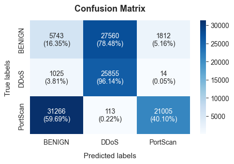

## Random Forest

Random Forest requires fewer structural changes when moving from binary to multiclass classification, as it natively supports multiple classes without requiring a reformulation of the learning objective. The same impurity criteria (e.g., Gini or entropy) are used to evaluate splits across all classes, and each tree learns to separate the full label space rather than a binary decision boundary.

In this study, the main adjustment concerned the handling of class imbalance through the class_weight parameter, which in the multiclass setting distributes weighting across several positive classes rather than a single positive class.

Additionally, prediction in the multiclass case relies on aggregating class probabilities across all trees and selecting the class with the highest averaged probability, which can amplify the impact of poorly represented classes if not properly balanced. Apart from these considerations, the model configuration remained largely unchanged, reinforcing Random Forest’s suitability as a robust baseline for multiclass intrusion detection tasks.

|  | Accuracy | PrecisionScore | RecallScore | F1Score | F1Weighted | MCC | TP_0 | FP_0 | FN_0 | TN_0 | TP_1 | FP_1 | FN_1 | TN_1 | TP_2 | FP_2 | FN_2 | TN_2 |
| --- | --- | --- | --- | --- | --- | --- | --- | --- | --- | --- | --- | --- | --- | --- | --- | --- | --- | --- |
| 0 | 0.999869 | 0.999855 | 0.999859 | 0.999857 | 0.999869 | 0.999795 | 35110 | 10 | 5 | 79268 | 26889 | 3 | 5 | 87496 | 52379 | 2 | 5 | 62007 |

The following table shows the computed feature importance ordered from highest to lowest.

|  | 0 | 1 | 2 | 3 | 4 | 5 | 6 | 7 | 8 |
| --- | --- | --- | --- | --- | --- | --- | --- | --- | --- |
| Feature | Subflow Fwd Bytes | Packet Length Std | Flow Packets/s | Flow Duration | Init_Win_bytes_backward | Subflow Fwd Packets | Init_Win_bytes_forward | Flow Bytes/s | Down/Up Ratio |
| Importance | 0.322 | 0.241 | 0.161 | 0.099 | 0.09 | 0.057 | 0.015 | 0.013 | 0.002 |

There is a noticeable difference in the importance attributed to features "Subflow Fwd Bytes" by each algorithm. "Subflow Fwd Bytes" measures how much forward data is transmitted within segments of a flow, providing insight into how traffic volume is distributed rather than just the total amount. A subflow is a segment of a larger flow. Malicious traffic flows (Class 1) tend to send less data forward per segment. This feature may reveal important patterns that can be captured by tree models such as Random Forest.

A confusion matrix is shown below for the model predictions obtained using the standard multiclass decision rule, where each observation is assigned to the class with the highest predicted probability.

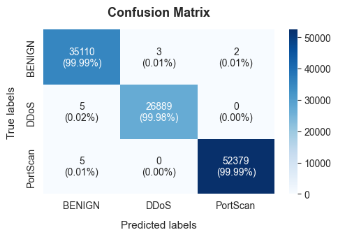

## XGBoost

XGBoost requires more explicit adaptation when transitioning from binary to multiclass classification, as the objective function must be redefined to handle multiple output classes simultaneously.

The XGBoost classifier was configured for multiclass learning using the multi:softprob objective and optimized via log-loss. Binary-specific balancing parameters such as scale_pos_weight were not used, as they are not applicable in a multiclass setting. Instead, model performance was controlled through hyperparameter tuning of tree complexity, learning rate, and subsampling ratios to mitigate overfitting and improve generalization across heterogeneous intrusion classes.

|  | Accuracy | PrecisionScore | RecallScore | F1Score | F1Weighted | MCC | TP_0 | FP_0 | FN_0 | TN_0 | TP_1 | FP_1 | FN_1 | TN_1 | TP_2 | FP_2 | FN_2 | TN_2 |
| --- | --- | --- | --- | --- | --- | --- | --- | --- | --- | --- | --- | --- | --- | --- | --- | --- | --- | --- |
| 0 | 0.999895 | 0.999887 | 0.999905 | 0.999896 | 0.999895 | 0.999836 | 35111 | 8 | 4 | 79270 | 26893 | 2 | 1 | 87497 | 52377 | 2 | 7 | 62007 |

The following table shows the computed feature importance from highest to lowest.

|  | 0 | 1 | 2 | 3 | 4 | 5 | 6 | 7 | 8 |
| --- | --- | --- | --- | --- | --- | --- | --- | --- | --- |
| Feature | Subflow Fwd Bytes | Packet Length Std | Init_Win_bytes_backward | Flow Duration | Flow Bytes/s | Init_Win_bytes_forward | Subflow Fwd Packets | Flow Packets/s | Down/Up Ratio |
| Importance | 1855.0 | 1048.0 | 695.0 | 372.0 | 211.0 | 144.0 | 106.0 | 95.0 | 63.0 |

A confusion matrix is shown below for the model predictions obtained using the standard multiclass decision rule, where each observation is assigned to the class with the highest predicted probability.

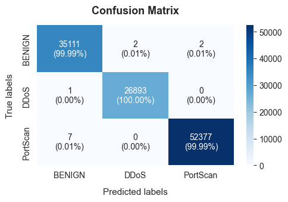

## LightGBM

Unlike binary classification, no direct equivalent of scale_pos_weight is used; instead, class imbalance was handled through class or sample weighting to ensure fair representation of minority class types during split optimization. Given LightGBM’s histogram-based learning strategy, such weighting is particularly important to prevent majority classes from dominating tree structure formation.

|  | Accuracy | PrecisionScore | RecallScore | F1Score | F1Weighted | MCC | TP_0 | FP_0 | FN_0 | TN_0 | TP_1 | FP_1 | FN_1 | TN_1 | TP_2 | FP_2 | FN_2 | TN_2 |
| --- | --- | --- | --- | --- | --- | --- | --- | --- | --- | --- | --- | --- | --- | --- | --- | --- | --- | --- |
| 0 | 0.999913 | 0.999899 | 0.999918 | 0.999909 | 0.999913 | 0.999864 | 35113 | 8 | 2 | 79270 | 26892 | 2 | 2 | 87497 | 52378 | 0 | 6 | 62009 |

The following table shows the computed feature importance from highest to lowest.

|  | 0 | 1 | 2 | 3 | 4 | 5 | 6 | 7 | 8 |
| --- | --- | --- | --- | --- | --- | --- | --- | --- | --- |
| Feature | Subflow Fwd Bytes | Packet Length Std | Init_Win_bytes_backward | Flow Duration | Flow Bytes/s | Init_Win_bytes_forward | Flow Packets/s | Subflow Fwd Packets | Down/Up Ratio |
| Importance | 8864520.0 | 6723577.0 | 4612852.0 | 1947786.0 | 1667660.0 | 704536.0 | 431376.0 | 430379.0 | 182107.0 |

A confusion matrix is shown below for the model predictions obtained using the standard multiclass decision rule, where each observation is assigned to the class with the highest predicted probability.

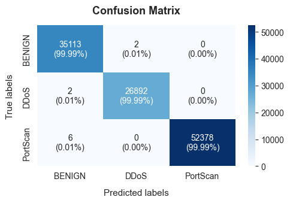

## CatBoost

CatBoost was applied using its native multiclass learning capability. Unlike XGBoost and LightGBM, CatBoost does not rely on binary-oriented weighting parameters such as scale_pos_weight; instead, class imbalance can be optionally addressed through auto_class_weights="Balanced". However, due to CatBoost’s ordered boosting mechanism, the model is generally more robust to class imbalance and reduces the need for extensive weight adjustments. Performance was evaluated using macro-averaged metrics and MCC to ensure fair assessment across all classes.

```
Fitting 3 folds for each of 9 candidates, totalling 27 fits
```

|  | Accuracy | PrecisionScore | RecallScore | F1Score | F1Weighted | MCC | TP_0 | FP_0 | FN_0 | TN_0 | TP_1 | FP_1 | FN_1 | TN_1 | TP_2 | FP_2 | FN_2 | TN_2 |
| --- | --- | --- | --- | --- | --- | --- | --- | --- | --- | --- | --- | --- | --- | --- | --- | --- | --- | --- |
| 0 | 0.998663 | 0.998589 | 0.998769 | 0.998679 | 0.998663 | 0.997913 | 35079 | 92 | 36 | 79186 | 26870 | 25 | 24 | 87474 | 52291 | 36 | 93 | 61973 |

The following table shows the computed feature importance from highest to lowest.

|  | 0 | 1 | 2 | 3 | 4 | 5 | 6 | 7 | 8 |
| --- | --- | --- | --- | --- | --- | --- | --- | --- | --- |
| Feature | Subflow Fwd Bytes | Packet Length Std | Init_Win_bytes_backward | Init_Win_bytes_forward | Flow Duration | Flow Packets/s | Flow Bytes/s | Subflow Fwd Packets | Down/Up Ratio |
| Importance | 29.0 | 29.0 | 18.0 | 6.0 | 5.0 | 4.0 | 4.0 | 4.0 | 2.0 |

A confusion matrix is shown below for the model predictions obtained using the standard multiclass decision rule, where each observation is assigned to the class with the highest predicted probability.

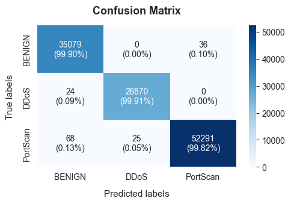

# Model Comparison and Selection

The next step is to define the desired model outcome for the multiclass intrusion detection task. Unlike binary classification, where the focus is on distinguishing between malicious traffic and normal traffic, the multiclass setting requires the model to correctly differentiate between normal traffic (BENIGN) and multiple malicious traffics (DDoS and PortScan). As a result, overall accuracy alone is not sufficient to evaluate performance, since it may hide poor performance on individual classes.

In this context, model selection is performed by first enforcing a class-specific recall, particularly for the malicious traffic categories (DDoS and PortScan), to ensure that malicious traffic is not missed. Among the models that satisfy these minimum recall requirements, the final selection is based on the best overall balance of F1Score and Matthews Correlation Coefficient (MCC), as these metrics provide a robust assessment of both class-wise performance and global predictive quality. This approach ensures that the selected model achieves strong detection performance across all malicious traffic types while maintaining a low rate of misclassification.

This selection strategy reflects a practical decision framework for multiclass security systems, where reliable detection of all malicious traffic categories is prioritized over raw accuracy, and performance is optimized under constraints that reflect operational security requirements.

|  | Model | Accuracy | PrecisionScore | RecallScore | F1Score | F1Weighted | MCC | TP_BENIGN | FP_BENIGN | FN_BENIGN | TN_BENIGN | TP_DDoS | FP_DDoS | FN_DDoS | TN_DDoS | TP_PortScan | FP_PortScan | FN_PortScan | TN_PortScan | Recall_DDoS | Recall_PortScan | LogLoss | BrierScoreLoss |
| --- | --- | --- | --- | --- | --- | --- | --- | --- | --- | --- | --- | --- | --- | --- | --- | --- | --- | --- | --- | --- | --- | --- | --- |
| 0 | LightGBM | 0.999913 | 0.999899 | 0.999918 | 0.999909 | 0.999913 | 0.999864 | 35113 | 8 | 2 | 79270 | 26892 | 2 | 2 | 87497 | 52378 | 0 | 6 | 62009 | 0.999926 | 0.999885 | 0.004452 | 0.000183 |
| 1 | XGBoost | 0.999895 | 0.999887 | 0.999905 | 0.999896 | 0.999895 | 0.999836 | 35111 | 8 | 4 | 79270 | 26893 | 2 | 1 | 87497 | 52377 | 2 | 7 | 62007 | 0.999963 | 0.999866 | 0.016165 | 0.000575 |
| 2 | Random Forest | 0.999869 | 0.999855 | 0.999859 | 0.999857 | 0.999869 | 0.999795 | 35110 | 10 | 5 | 79268 | 26889 | 3 | 5 | 87496 | 52379 | 2 | 5 | 62007 | 0.999814 | 0.999905 | 0.001101 | 0.000258 |
| 3 | CatBoost | 0.998663 | 0.998589 | 0.998769 | 0.998679 | 0.998663 | 0.997913 | 35079 | 92 | 36 | 79186 | 26870 | 25 | 24 | 87474 | 52291 | 36 | 93 | 61973 | 0.999108 | 0.998225 | 0.010123 | 0.002508 |

The performance comparison of the evaluated models shows consistently high results across tree-based ensemble methods, with LightGBM, XGBoost, Random Forest and CatBoost all achieving near-perfect classification performance on the multiclass intrusion detection task. In contrast, Logistic Regression performs significantly worse across all aggregate metrics, confirming that linear decision boundaries are insufficient to capture the complexity of network traffic patterns in this dataset.

Among all models, LightGBM achieves the best overall performance, obtaining the highest values for F1Score, Recall, and MCC. Random Forest achieved a lower LogLoss, indicating marginally better probabilistic calibration. Given that the primary objective is accurate detection of malicious traffic, classification performance takes precedence over minor differences in probability estimates.

From a security perspective, all tree-based models demonstrate extremely high recall for the malicious traffic (DDoS and PortScan), which is a critical requirement in intrusion detection systems. LightGBM and XGBoost both achieve near-perfect recall for DDoS traffic, while CatBoost show slightly lower but still highly competitive performance.

Overall, the results confirm that ensemble tree-based methods are significantly more suitable for multiclass network intrusion detection than linear models, with LightGBM providing the most stable and well-rounded performance under the defined evaluation framework.

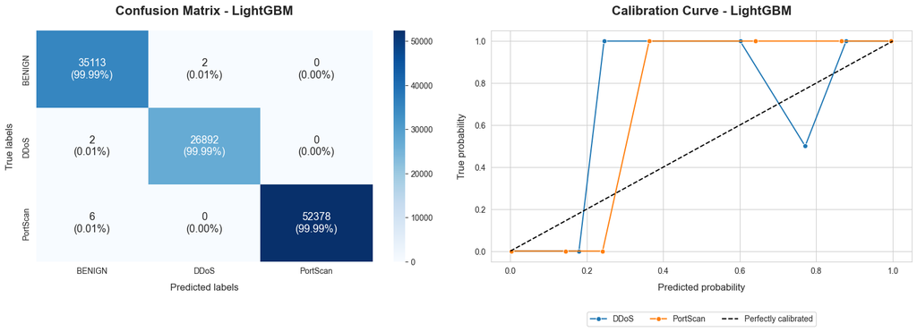

The confusion matrix shows that the model achieves near-perfect classification across all three classes. BENIGN traffic is correctly classified in 99.99% of cases, with only a negligible number of misclassifications into malicious traffic classes. DDoS attacks are detected with almost perfect recall (99.99%). PortScan malicious traffic is also identified with near-perfect accuracy (99.99%), with only a minimal number of instances incorrectly classified as BENIGN.

Importantly, there is no confusion between malicious traffic classes, meaning that DDoS and PortScan are not misclassified as each other. This is particularly relevant in a cybersecurity context, where distinguishing between different malicious traffic types is essential for appropriate response. Overall, the confusion matrix confirms that the model satisfies the primary requirement of maximizing malicious traffic detection while maintaining extremely low false positive and false negative rates.

The calibration curve evaluates how well the predicted probabilities reflect the true likelihood of each class. The model produces highly confident predictions for DDoS, with most probabilities concentrated near extreme values. While the curve shows some instability in intermediate probability ranges due to limited samples, the alignment at high-confidence regions indicates that predictions are reliable where it matters most. The PortScan calibration curve indicates that the model assigns very high probabilities in a step-like curve, reflecting strong class separability rather than poor calibration.

The calibration curves non-smooth behavior is primarily due to the model producing highly confident predictions, with most probability estimates concentrated near 0 and 1. The model shows strong alignment with the ideal calibration line at both low and high probability regions, which are the most relevant for decision-making. Overall, the calibration results indicate that the model is well-calibrated in practice, with deviations largely attributable to the high separability of the classes rather than systematic bias in probability estimation.

# Feature Importance Analysis

To better understand the behavior of the selected model, a feature importance analysis was conducted. This step aims to identify which variables contribute most to the model’s predictions and to assess whether these contributions are consistent with the patterns observed during the exploratory data analysis.

The analysis reveals that a small subset of features dominates the model’s decision-making process. In particular, Subflow Fwd Bytes and Packet Length Std stand out as the most influential features across the top-performing models, with importance scores significantly higher than all other variables. This dominance indicates that traffic volume and variability in packet size are critical factors in distinguishing between traffic classes.

This finding is consistent with earlier observations from the ANOVA analysis and boxplot exploration, where BENIGN traffic exhibited a wide spread with numerous outliers, DDoS traffic showed a wider distribution with minimal overlap, and PortScan traffic was highly concentrated in lower value ranges. The clear separation in feature distributions across classes explains why these variables provide such strong discriminative power.

# Error and Calibration Analysis

Although the selected model achieves near-perfect classification performance, a closer inspection of the confusion matrix provides insight into the few remaining misclassifications. This analysis helps identify potential edge cases and assess whether the observed errors pose any practical concern.

The observed errors follow a consistent pattern: misclassifications occur mainly between BENIGN and PortScan traffic, suggesting that certain PortScan patterns share characteristics with normal network behavior. In contrast, DDoS traffic exhibits highly distinctive patterns and remains well separated in the feature space, resulting in highly reliable detection. The absence of meaningful confusion between DDoS and PortScan further demonstrates the model’s ability to discriminate between different types of malicious traffic.

# Final Evaluation and Conclusion

This study developed and evaluated a multiclass classification model for flow-based network intrusion detection, with the objective of accurately distinguishing between BENIGN traffic, DDoS attacks and PortScan activity.

The evaluation of the selected model confirmed its effectiveness. The confusion matrix demonstrated near-perfect classification with negligible misclassification and no confusion between malicious traffic types. The calibration analysis further showed that predicted probabilities are well aligned with observed outcomes, particularly in high-confidence regions, indicating reliable probabilistic outputs.

Feature importance analysis revealed that a small number of variables, notably Subflow Fwd Bytes and Packet Length Std, play a dominant role in the model’s decisions. These findings are consistent with earlier statistical analysis and reflect meaningful patterns in network traffic behavior.

Finally, error analysis confirmed that the few remaining misclassifications are limited to edge cases, primarily involving borderline distinctions between BENIGN and PortScan traffic, with almost no impact on the detection of DDoS attacks.

Overall, the selected model demonstrates high predictive performance, strong reliability, and clear interpretability. These characteristics make it a suitable candidate for deployment in real-world intrusion detection systems, where accurate malicious traffic detection and trustworthy probability estimates are essential.